# TF3_顧客分群

第十一組

2019-06-18 21:27:05

##### Setup

在進行分析之前，先安裝以下基本套件

```r
packages = c(
  "dplyr","ggplot2","googleVis","devtools","magrittr","caTools","ROCR","caTools")
existing = as.character(installed.packages()[,1])
for(pkg in packages[!(packages %in% existing)]) install.packages(pkg)

if(!is.element("chorddiag", existing))
  devtools::install_github("mattflor/chorddiag")
```

##### Library

```r
rm(list=ls(all=T))
options(digits=4, scipen=12)
load("data/tf2.rdata")
load("data/tf3.rdata")
library(dplyr)
library(ggplot2)
library(caTools)
library(ROCR)
library(googleVis)
library(chorddiag)
```

##### 2.1 K-means顧客分群

在此我們用的是集群式分析k-means，將資料依照不同屬性將顧客做分群。 k-means分完群會把分群的向量放在“cluster”這個欄位裡面，用table(D$grp)看族群大小。

**RFM**

- 觀察出來，分成5群是最能進行行銷策略且有明顯群間差距的分群方式

```r
set.seed(111)

D$grp = D %>%
  select(r,s,f,m,rev,raw, starts_with("p"), avgPrice, cycle, mon1, mon2, mon3) %>%
  scale %>%
  kmeans(., 5) %>%
  .$cluster
# D$grp = kmeans(scale(D[,2:4]),10)$cluster

table(D$grp)  # 族群大小
```

```
##
##     1     2     3     4     5
##   545  3146  6804  5472 12564
```

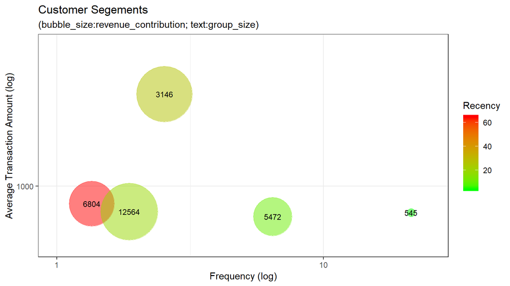

```r
group_by(D, grp) %>% summarise(
  recent=mean(r),
  freq=mean(f),
  money=mean(m),
  senior=mean(s),
  avgPrice=mean(avgPrice),
  cycle=mean(cycle),
  mon1=mean(mon1),
  mon2=mean(mon2),
  mon3=mean(mon3),
  size=n() ) %>%
  mutate( revenue = size*money/1000 )  %>%
  filter(size > 1) %>%
  ggplot(aes(x=freq, y=money)) +
  geom_point(aes(size=revenue, col=recent),alpha=0.5) +
  scale_size(range=c(4,30)) +
  scale_color_gradient(low="green",high="red") +
  scale_x_log10(limits=c(1,25)) + scale_y_log10(limits=c(500,5000)) +
  geom_text(aes(label = size ),size=3) +
  theme_bw() + guides(size=F) +
  labs(title="Customer Segements",
       subtitle="(bubble_size:revenue_contribution; text:group_size)",
       color="Recency") +
  xlab("Frequency (log)") + ylab("Average Transaction Amount (log)")
```

圖形解析：

因此，從這些泡泡圖，我們可以知道營收來源主要來自於哪裡。藉此來看出我們的行銷重點應該放在哪一些客群上。

##### 計算每一群的顧客特性

- 我們用以下變數區別不同族群的屬性
- recent（最後一次購買距今天數）
- senior（第一次購買距今天數）
- freq（購買次數）
- money（平均購買金額）
- profit（平均獲利）
- avgPrice（購買商品平均單價）
- in114_115（顧客居住區域是否在z114，z115）
- cycle（平均多少天購買一次）
- mon1、mon2、mon3（第一、二、三個月的平均購買次數）
- hotProd
- CHR（聖誕節前一週購買次數）

```r
K = group_by(D, grp) %>% summarise(
  recent=mean(r),
  senior = mean(s),
  freq=mean(f),
  money=mean(m),
  profit=mean(raw/f),
  avgPrice=mean(avgPrice),
  in114_115=mean(in114_115),
  cycle=mean(cycle),
  mon1=mean(mon1),
  mon2=mean(mon2),
  mon3=mean(mon3),
  hotProd=mean(p1+p2+p3+p4+p5+p6+p7+p8+p9+p10),
  CHR = mean(CHR),
  size=n()
  )
K
```

```
## # A tibble: 5 x 15
##     grp recent senior  freq money profit avgPrice in114_115 cycle  mon1
##   <int>  <dbl>  <dbl> <dbl> <dbl>  <dbl>    <dbl>     <dbl> <dbl> <dbl>
## 1     1   3.89   86.4 21.3   740.   116.    106.      0.549  4.77 6.48
## 2     2  26.6    58.9  2.53 2844.   517.    233.      0.327 28.2  0.696
## 3     3  64.7    73.1  1.35  817.   127.    100.      0.369 60.7  0.952
## 4     4  10.7    79.4  6.45  707.   101.     98.3     0.495 14.5  2.08
## 5     5  19.0    38.7  1.87  747.   112.    101.      0.410 21.8  0.249
## # ... with 5 more variables: mon2 <dbl>, mon3 <dbl>, hotProd <dbl>,
## #   CHR <dbl>, size <int>
```

##### 各族群的地區分布

- grp1忠實顧客主要在115、221與未知，且住在115區的比例為五群中最高
- Grp4省錢族顧客主要居住在115區和221區

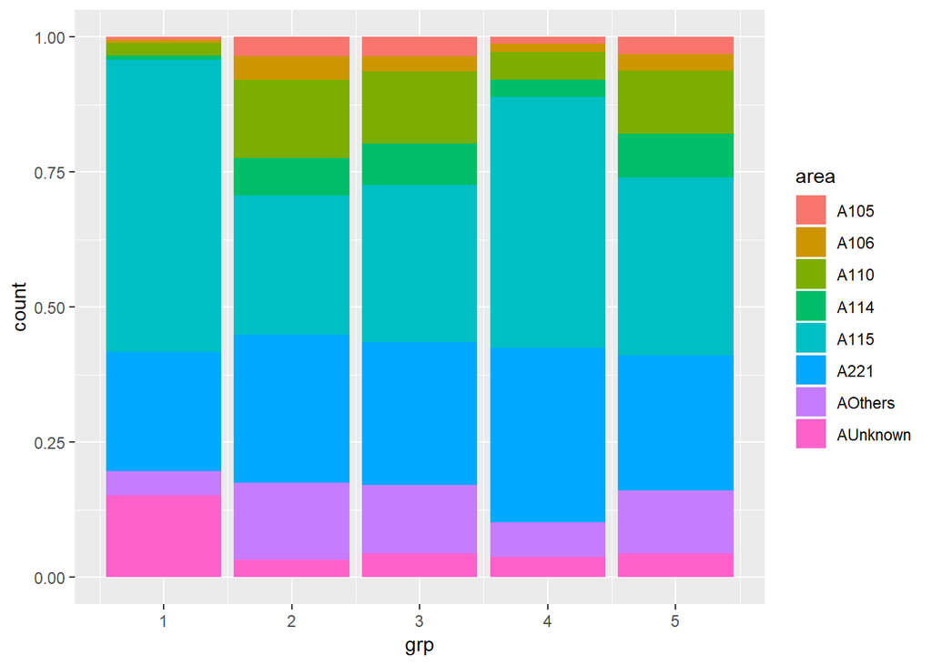

```r
ggplot(D, aes(grp, fill=area)) + geom_bar(position="fill")
```

##### 各族群的平日/假日購買偏好

(Na: 沒有特別偏好平日或假日)

- grp2高金字塔客群與grp3流失顧客（散客）也偏好在週末消費，各佔該族群的四成左右比例
- grp1忠實顧客偏好在平日消費，約佔該族群的九成。
- grp4省錢族也偏好在平日消費，佔該群約七成。

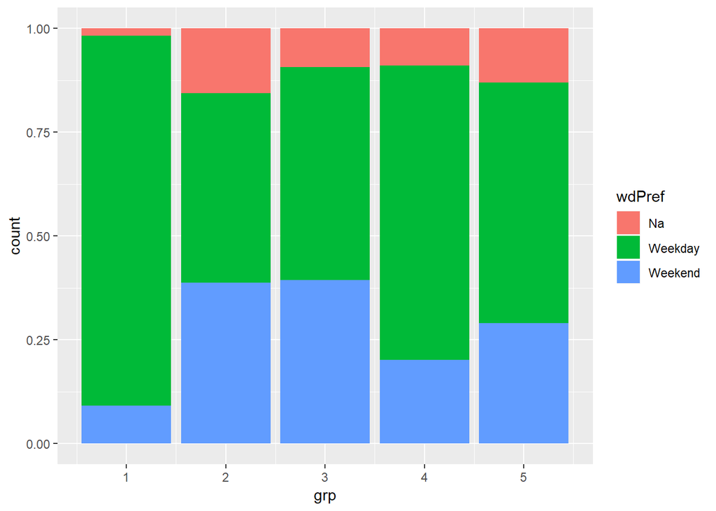

```r
ggplot(D, aes(grp, fill=wdPref)) + geom_bar(position="fill")
```

##### 各族群的年齡分布

- grp1忠實顧客的年輕族群偏少，以中、老年族群居多
- grp2高金字塔族群以年輕+中年族群佔絕大多數，老年族群比例為五群中最低
- Grp4省錢族中老年族群比例為五群中最高

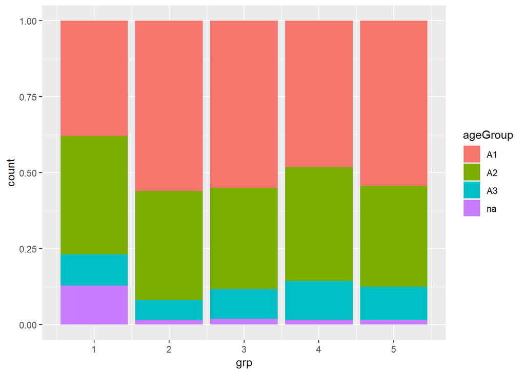

```r
D$ageGroup<-factor(D$age, levels=c("a20", "a25", "a30", "a35","a40", "a45", "a50", "a55", "a60", "a65", "na"),
                          labels=c("A1" ,  "A1",  "A1",  "A1", "A2",  "A2",  "A2",  "A3",  "A3",  "A3", "na"))

ggplot(D, aes(grp, fill=ageGroup)) + geom_bar(position="fill")
```

### 3. 顧客分群特徵

##### 3.1 不同客戶群其消費習慣

```r
P = group_by(D, grp) %>% summarise(
  size=n(),                          ## 族群大小
  buyProb=mean(Buy),                 ## 預測3月會回購的機率
  revPred=mean(Rev),                 ## 預測3月會花費多少
  totalRev=mean(rev),                ## 總收入
  totalCost=mean(rev-raw),           ## 總成本
  totalProfit=mean(raw),             ## 總毛利
  costRate=mean((rev-raw)/rev),      ## 成本率
  profitRate=mean(raw/rev),          ## 毛利率
  freq=mean(f),                      ## 頻率
  avgRev=mean(rev/f),                ## 平均每次消費收入
  avgCost=mean((rev-raw)/f),         ## 平均每次消費成本
  avgProfit=mean(raw/f)              ## 平均每次消費利潤
  )
P
```

```
## # A tibble: 5 x 13
##     grp  size buyProb revPred totalRev totalCost totalProfit costRate
##   <int> <int>   <dbl>   <dbl>    <dbl>     <dbl>       <dbl>    <dbl>
## 1     1   545   0.981   4150.   14193.    12013.       2180.    0.854
## 2     2  3146   0.439   1800.    6282.     5145.       1137.    0.819
## 3     3  6804   0.296    754.    1053.      891.        162.    0.872
## 4     4  5472   0.785   1057.    4276.     3657.        619.    0.873
## 5     5 12564   0.396    729.    1283.     1094.        189.    0.877
## # ... with 5 more variables: profitRate <dbl>, freq <dbl>, avgRev <dbl>,
## #   avgCost <dbl>, avgProfit <dbl>
```

##### 分群特徵

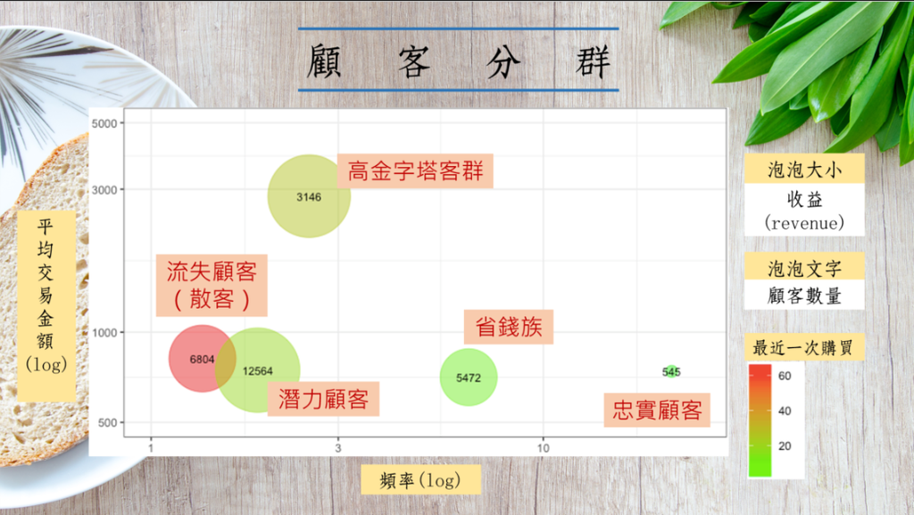

Fig-2: Customer Clustering

針對各族群的特性我們將五群顧客分別命名為

1. 消費頻率最高的忠誠顧客
2. 客單價最高的高金字塔顧客
3. 消費頻率最低、最近一次購買天數距今最久的流失顧客
4. 客單價最低、消費頻率次高的省錢顧客
5. 首購日距今最短的潛力顧客

##### **高金字塔客群**

高金字塔客群 (grp=2)的特性： + 平均1個月購買一次，單次消費力最高，單次獲利與購買產品單價也最高。 + 此族群的居住地區與購買次數較無關。 + 假日購買比率偏高。 + 中年族群較多。 + 可能的行銷策略：高級會員制、節慶禮

##### **流失顧客**

流失顧客(散客) (grp=3) + 消費頻率頻率最低，只有第一個月有來購買，後兩個月則較少來。三個月的購買次數遞減。 + 最近一次購買距今天數(recent)最長。 + 平均2個月購買一次。 + 族群次大，地區與購買次數較無關 + 年輕族群較多 + 偏向假日購買->可能以遊客居多 + 行銷策略：刺激此族群回頭購買(提高消費頻率)

##### 族群特性總表

[figure not shown]

Fig-2: Table of Customer Characteristics

##### 儲存資料

```r
save(P, D, file="data/tf3.rdata")
```